# Alcohol Consumption and Average Grades

Karan Vijay Kashyap, Sandile Nhlalo-Sibanda

August, 2022

# Introduction

This project seeks to reproduce the research previously done on the determination of whether alcohol consumption has any prognostic significance over average student grades. We’re also interested in duplicating the original study to verify the correctness and if additional characteristics are significant predictors of student grades. Like the original author, we will not attempt to estimate student grade progression over marking periods because all of the dataset’s attributes (except grades) stay consistent between marking periods and are fundamental descriptors of student backgrounds.

The project is organization of the project will follow the outline that resembles that of the original research’s author (though will have some additions and some subtractions). The general structure will be as follows:

In the beginning, we will start with exploratory data analysis to see if the two tables (with math and Portuguese grades from original dataset) and (with math and english grades from survey dataset) may be combined.

We will then derive student average grades throughout grading periods by integrating the two tables and estimate three models: Linear Model, Regression Tree Model, and Random Forest Model.

Later, we acquired data from a survey for English and Math grades, and we will replicate the research on a fresh data set, estimating three models: Linear Model, Regression Tree Model, and Random Forest Model.

The goal of this study is to determine the effect of alcohol use on students’ average grades.

# About Data

Original Dataset: We have two csv file one for math grade and other for Portuguese grade which collected from two school and merged in one csv file based on subject. Number of Columns: Both dataset have 33 columns Number of Rows: Maths dataset: 395, Portugese dataset: 649 Kaggle Link: “https://www.kaggle.com/code/calcifer/alcohol-consumption-and-average-grades/notebook”

Survey Dataset: We have collected data using Google survey for math grade and english grade from our school friend from school name Ryan “R” and Johntallch “J”. Number of Columns: Both dataset have 33 columns Number of Rows: Both dataset have 105 rows

# Exploratory Data Analysis

In this Exploratory Data Analysis, we will undertake preliminary investigations on original and collected datasets in order to uncover patterns, spot anomalies, test hypotheses, and evaluate assumptions using summary statistics and graphical representations.

## Data Import

Original Dataset We will import the data from a delimited csv file, we have original data set “student-mat.csv” which contains maths grades and “student-por.csv” which contains Portuguese grade, All column name are similar in both the data set.

New Dataset We will import the data from a delimited csv file, we have gathered new data set “Student_Maths.csv” which contains maths grades and “Student_English.csv” which contains English grade, All column name are similar in both the data set.

## Original Data Table View

In original Data Table, Please find complete details about the column name: Student’s school (binary: ‘GP’ - Gabriel Pereira or ‘MS’ - Mousinho da Silveira), sex: “M” - Male, “F” - Female, age: student age ,Address:“U” - Urban,“R” Rural, famsize: - “GT3” - Greater than 3, “LT3” - Less than 3, Pstatus (Parent cohabitation Status): “T”: Together, “A”: Apart, Medu (Mother Education):(numeric: 0 - none, 1 - primary education (4th grade), 2 - 5th to 9th grade, 3 - secondary to higher secondary, 4 - University and above, Fedu (Father’s education): (numeric: 0 - none, 1 - primary education (4th grade), 2 - 5th to 9th grade, 3 - secondary to higher secondary, 4 - University and above, Mjob (Mother’s job): at_home,teacher,services,health,other, Fjob (Father’s Job): at_home,teacher,services,health,other, reason (reason to choose this school): close to home, school repuation, course preference,other, traveltime - Home to school travel time (numeric: 1 - upto 15 min., 2 - 15 to 30 min., 3 - 30 min. to 1 hour, or 4 - above 1 hour), studytime - Weekly study time (numeric: 1 - less than 2 hours, 2 - 2 to 5 hours, 3 - 5 to 10 hours, or 4 - more than 10 hours), failures - Number of past class failures: 1,2,3,4, schoolsup - Extra educational support (binary: yes or no), famsup - Family educational support (binary: yes or no), activities - Extra-curricular activities (binary: yes or no),nursery - Attended nursery school (binary: yes or no), higher - Wants to take higher education (binary: yes or no),internet - Internet access at home (binary: yes or no), romantic - With a romantic relationship (binary: yes or no), freetime - Free time after school (numeric: from 1 - very low to 5 - very high), goout - Going out with friends (numeric: from 1 - very low to 5 - very high), Dalc - Workday alcohol consumption (numeric: from 1 - very low to 5 - very high), Walc - Weekend alcohol consumption (numeric: from 1 - very low to 5 - very high), health - Current health status (numeric: from 1 - very bad to 5 - very good), G1 - First period grade (numeric: from 0 to 20), G2 - Second period grade (numeric: from 0 to 20), G3 - Final grade (numeric: from 0 to 20, output target).

Original Data set

| school | sex | age | address | famsize | Pstatus | Medu | Fedu | Mjob | Fjob | reason | nursery | internet | guardian | traveltime | studytime | failures | schoolsup | famsup | activities | higher | romantic | famrel | freetime | goout | Dalc | Walc | health | absences | paid.x | … |
| --- | --- | --- | --- | --- | --- | --- | --- | --- | --- | --- | --- | --- | --- | --- | --- | --- | --- | --- | --- | --- | --- | --- | --- | --- | --- | --- | --- | --- | --- | --- |
| GP | F | 15 | R | GT3 | T | 2 | 2 | at_home | other | reputation | yes | no | mother | 1 | 1 | 0 | yes | yes | yes | yes | no | 4 | 3 | 1 | 1 | 1 | 2 | 8 | yes | … |
| GP | F | 15 | R | GT3 | T | 2 | 4 | services | health | course | yes | yes | mother | 1 | 3 | 0 | yes | yes | yes | yes | no | 4 | 3 | 2 | 1 | 1 | 5 | 2 | yes | … |
| GP | F | 15 | R | GT3 | T | 3 | 4 | services | health | course | yes | yes | mother | 1 | 3 | 0 | yes | yes | yes | yes | no | 4 | 3 | 2 | 1 | 1 | 5 | 2 | yes | … |
| GP | F | 15 | U | GT3 | A | 3 | 3 | other | health | reputation | yes | no | father | 1 | 4 | 0 | yes | no | no | yes | no | 4 | 3 | 3 | 1 | 1 | 4 | 10 | no | … |
| GP | F | 15 | U | GT3 | A | 4 | 3 | services | services | reputation | yes | yes | mother | 1 | 2 | 0 | no | yes | yes | yes | no | 4 | 3 | 2 | 1 | 1 | 1 | 0 | yes | … |

## New Survey Data Table View

In new dataset, school “R”: ‘Ryan’, “J”:Johntallch, rest variable name remain same as that of original dataset.

New Data set

| school | sex | age | address | famsize | Pstatus | Medu | Fedu | Mjob | Fjob | reason | nursery | internet | guardian | traveltime | studytime | failures | schoolsup | famsup | activities | higher | romantic | famrel | freetime | goout | Dalc | Walc | health | absences | paid.x | … |
| --- | --- | --- | --- | --- | --- | --- | --- | --- | --- | --- | --- | --- | --- | --- | --- | --- | --- | --- | --- | --- | --- | --- | --- | --- | --- | --- | --- | --- | --- | --- |
| J | F | 15 | R | LE3 | T | 4 | 2 | health | services | course | yes | yes | mother | 2 | 2 | 0 | no | no | no | yes | no | 5 | 2 | 3 | 1 | 3 | 3 | 1 | no | … |
| J | F | 15 | U | GT3 | T | 4 | 4 | teacher | teacher | reputation | yes | yes | mother | 1 | 1 | 0 | no | yes | yes | yes | no | 3 | 3 | 4 | 2 | 4 | 5 | 2 | no | … |
| J | F | 16 | R | GT3 | T | 1 | 1 | services | services | home | yes | yes | father | 1 | 1 | 0 | yes | yes | yes | yes | no | 5 | 3 | 2 | 2 | 2 | 5 | 0 | no | … |
| J | F | 16 | R | GT3 | T | 2 | 1 | other | other | course | no | yes | mother | 2 | 2 | 0 | no | no | yes | yes | yes | 4 | 3 | 3 | 1 | 3 | 4 | 2 | no | … |
| J | F | 16 | R | GT3 | T | 2 | 2 | other | other | home | yes | yes | mother | 1 | 4 | 0 | no | yes | yes | yes | no | 4 | 5 | 5 | 2 | 4 | 5 | 2 | no | … |

# Data Visualization

## Scatter Plot of grade comparision

Please see the scatter plot representations side by side on the left for the original dataset and on the right for the new survey data set. Below we have commented on our thoughts on the new survey data set and also offered the author’s thoughts on the original data scatter plot.

Original Dataset: The two scatter plots from original dataset have little meaning. First, none of the 85 students consumed excessive amounts of alcohol on a regular basis. Second, practically all of those who had pretty high scores consumed very little alcohol over the week. Third, math and Portuguese grades appear to be substantially correlated. The corrected R-squared is 0.55 when I regress Portuguese grades on math grades. This suggests that the correlation coefficient between math and Portuguese grades is around 0.74, and that change in math grades may explain approximately 55% of the variance in Portuguese grades. This, in my opinion, indicates that I may proceed with combining the two tables

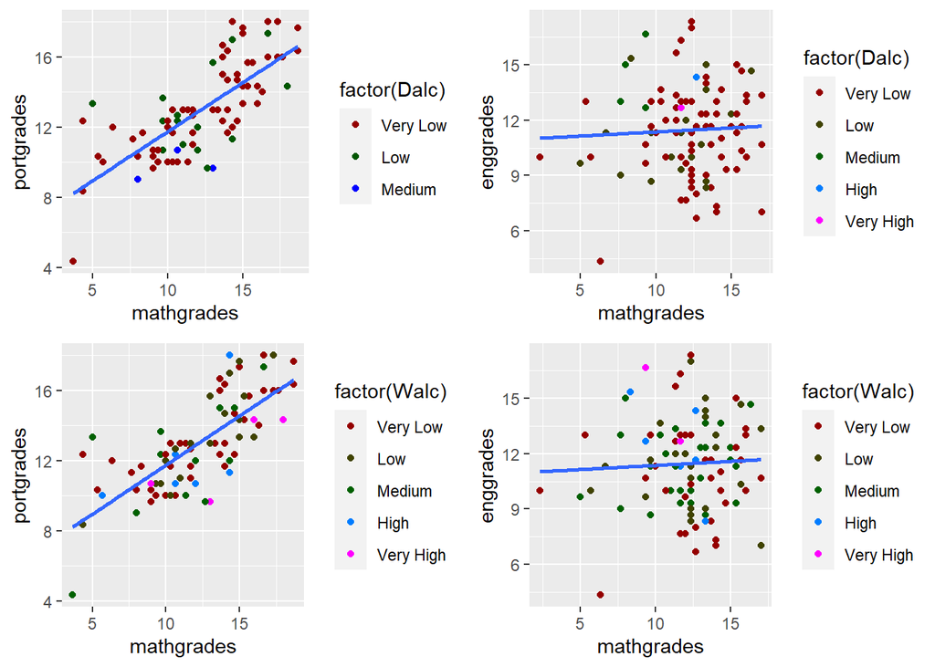

## Boxplot of average subject grades by daily alcohol consumption.

Please see the basic plot representations below for the original dataset and for the new survey data set. Below we have commented on our thoughts on the new survey data set and also offered the author’s thoughts on the original basic box plot. Original Dataset: The median average grade is noticeably higher among students who consume relatively little alcohol on a regular basis. The median grade of students with medium, high, and very high levels of daily alcohol intake, on the other hand, did not appear to be significantly different. As my first attempt at predicting average grades using all other factors, I will 1) do a multiple linear regression and 2) construct a regression tree of average grades on all other variables.Because variable “failures” is closely connected to my goal variable, avggrades, and both indicate the same general student aptitude (therefore it is more of a target than a feature), I am likely to delete variable “failures” from the dataset.

New Survey Dataset: Unlike the original dataset, The median average grade differs significantly and is somewhat of an inverted normal distribution looking at it as students who consume relatively little alcohol and those who consume relatively high volumes of alcohol appear to have high Median average grades. Students who however have medium average consumption seem to have the lowest median average grades compared to the rest, thereby producing an inverted bell shaped distribution. It is however of key point to note that the distribution spread in average grades decreases with increased alcohol consumption as we see a decreased number of outliers as the intake scale increases, together with the shrink in the IQR ranges as well

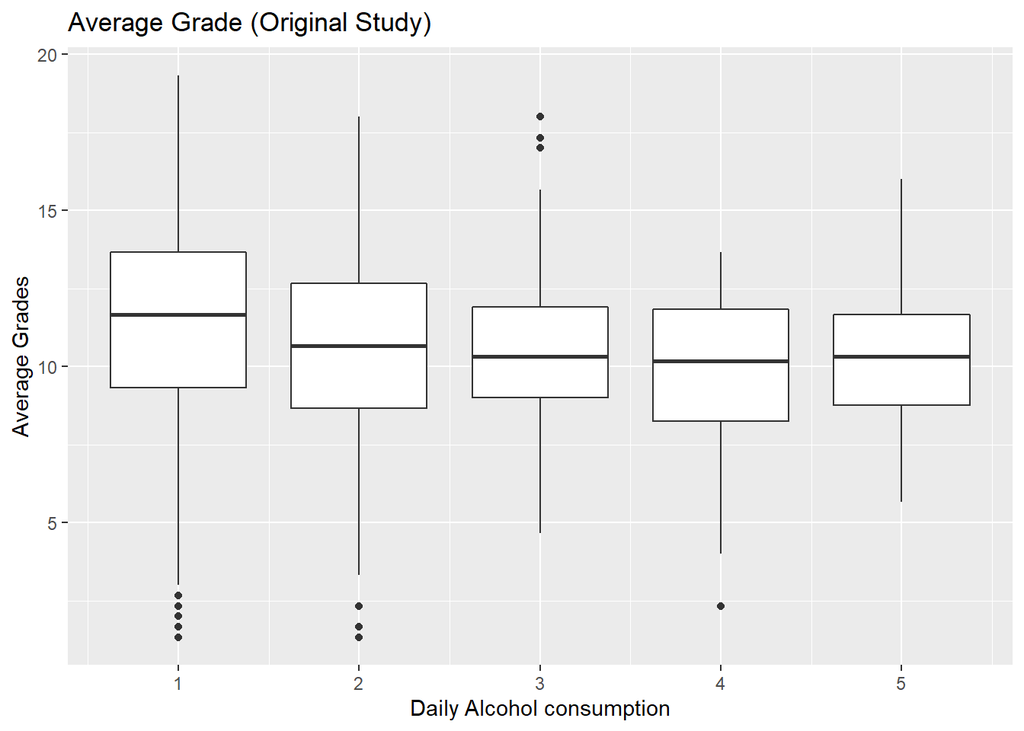

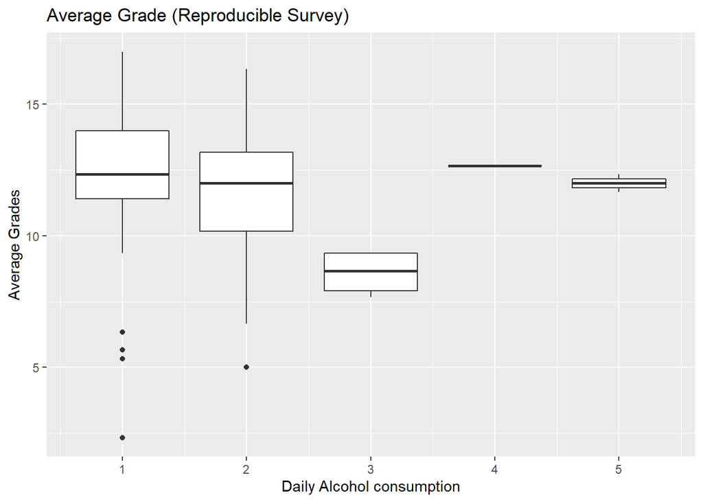

# Adjusted R-squared

Below we have commented on our thoughts on the new survey data set and also offered the author’s thoughts on the original data result of adjusted R-squared

Original Dataset: In the preceding regression, the adjusted R-squared is just 0.17, which is fairly low. It means that variance in everything else explains just 17% of the variation in average grades. Studytime, schoolsup, paid, and higher are the variables that have a statistically significant influence on average grade.

New Survey Dataset: In the below regression, the adjusted R-squared is 0.28, which is not very high but better than the original dataset. It means that variance in everything else explains just 28% of the variation in average grades. School, Mjob, absences are the variable that have a statistically significant influence over grade.

```
##
## Call:
## lm(formula = avggrades ~ ., data = d3norepeats[, 1:30])
##
## Residuals:
##      Min       1Q   Median       3Q      Max
## -10.8048  -1.5890   0.1455   1.8676   8.4868
##
## Coefficients:
##                    Estimate Std. Error t value Pr(>|t|)
## (Intercept)      10.6017499  1.8139110   5.845 7.04e-09 ***
## schoolMS         -0.3723012  0.2574810  -1.446  0.14854
## sexM             -0.1215773  0.2255528  -0.539  0.59000
## age              -0.1198027  0.0906465  -1.322  0.18661
## addressU          0.2930648  0.2427090   1.207  0.22756
## famsizeLE3        0.4975437  0.2219491   2.242  0.02522 *
## PstatusT          0.0640413  0.3168516   0.202  0.83987
## Medu              0.1848194  0.1396447   1.323  0.18600
## Fedu              0.1642152  0.1234646   1.330  0.18383
## Mjobhealth        0.7195927  0.4873500   1.477  0.14014
## Mjobother         0.0878501  0.2874717   0.306  0.75998
## Mjobservices      0.3595006  0.3392675   1.060  0.28959
## Mjobteacher       0.1089511  0.4567083   0.239  0.81150
## Fjobhealth       -0.2298997  0.6841685  -0.336  0.73693
## Fjobother         0.0004672  0.4281211   0.001  0.99913
## Fjobservices     -0.2993809  0.4493361  -0.666  0.50540
## Fjobteacher       1.1650673  0.6051943   1.925  0.05452 .
## reasonhome        0.2418873  0.2555691   0.946  0.34416
## reasonother       0.3335054  0.3412013   0.977  0.32861
## reasonreputation  0.4954622  0.2654763   1.866  0.06232 .
## guardianmother   -0.1771667  0.2439794  -0.726  0.46793
## guardianother    -0.2497580  0.4596099  -0.543  0.58698
## traveltime       -0.1100901  0.1449817  -0.759  0.44785
## studytime         0.5080568  0.1272501   3.993 7.06e-05 ***
## schoolsupyes     -1.5979812  0.3190187  -5.009 6.56e-07 ***
## famsupyes        -0.3691163  0.2091140  -1.765  0.07787 .
## paidyes          -0.6938560  0.2413583  -2.875  0.00414 **
## activitiesyes     0.0980887  0.2022346   0.485  0.62777
## nurseryyes        0.0309093  0.2473158   0.125  0.90057
## higheryes         1.9236766  0.3618564   5.316 1.33e-07 ***
## internetyes       0.4269133  0.2569866   1.661  0.09701 .
## romanticyes      -0.4996783  0.2097075  -2.383  0.01739 *
## famrel            0.1569738  0.1056496   1.486  0.13768
## freetime         -0.0399315  0.1029791  -0.388  0.69828
## goout            -0.2127131  0.0995379  -2.137  0.03286 *
## Dalc             -0.1303141  0.1389503  -0.938  0.34857
## Walc             -0.0210543  0.1092166  -0.193  0.84718
## health           -0.1562929  0.0709717  -2.202  0.02790 *
## absences         -0.0181346  0.0162657  -1.115  0.26519
## ---
## Signif. codes:  0 '***' 0.001 '**' 0.01 '*' 0.05 '.' 0.1 ' ' 1
##
## Residual standard error: 2.943 on 920 degrees of freedom
## Multiple R-squared:  0.2015, Adjusted R-squared:  0.1685
## F-statistic:  6.11 on 38 and 920 DF,  p-value: < 2.2e-16
```

```
## [1] 0.7984877
```

```
## [1] 0.849412
```

In the original, It seems that the linear model performs better than the regression tree as shown by the NMSE values.

```
##
## Call:
## lm(formula = avggrades ~ ., data = data_combine_norepeats[, 1:30])
##
## Residuals:
##     Min      1Q  Median      3Q     Max
## -6.1525 -1.2884  0.2205  1.2280  3.4728
##
## Coefficients:
##                   Estimate Std. Error t value Pr(>|t|)
## (Intercept)       6.699643   5.303053   1.263  0.21091
## schoolR           2.174254   0.651962   3.335  0.00140 **
## sexM             -0.856202   0.578448  -1.480  0.14359
## age               0.255114   0.248082   1.028  0.30754
## addressU         -0.313703   0.561106  -0.559  0.57800
## famsizeLE3        0.687955   0.634065   1.085  0.28187
## PstatusT         -0.559557   0.791204  -0.707  0.48192
## Medu              0.401696   0.295575   1.359  0.17876
## Fedu             -0.197905   0.264112  -0.749  0.45633
## Mjobhealth        5.112550   1.788593   2.858  0.00569 **
## Mjobother         3.194204   1.737500   1.838  0.07050 .
## Mjobservices      4.406977   1.676273   2.629  0.01064 *
## Mjobteacher       3.767140   1.810009   2.081  0.04129 *
## Fjobhealth        0.406175   1.562734   0.260  0.79574
## Fjobother         0.801976   1.442613   0.556  0.58015
## Fjobservices      0.323036   1.422576   0.227  0.82106
## Fjobteacher      -0.419975   1.840357  -0.228  0.82019
## reasonhome        0.193061   0.767923   0.251  0.80228
## reasonother       0.941515   1.015119   0.927  0.35705
## reasonreputation -0.003534   0.709662  -0.005  0.99604
## guardianmother    0.376808   0.701887   0.537  0.59318
## guardianother     0.025357   1.898435   0.013  0.98938
## traveltime       -0.581384   0.375643  -1.548  0.12648
## studytime        -0.224180   0.323400  -0.693  0.49062
## schoolsupyes      0.384467   1.112250   0.346  0.73069
## famsupyes        -0.607564   0.641553  -0.947  0.34708
## paidyes           0.020309   0.816635   0.025  0.98023
## activitiesyes     0.224808   0.557537   0.403  0.68809
## nurseryyes        0.073537   0.804376   0.091  0.92743
## higheryes        -2.720411   3.043795  -0.894  0.37470
## internetyes       1.106608   0.807362   1.371  0.17513
## romanticyes       0.417116   0.692637   0.602  0.54909
## famrel           -0.124433   0.334903  -0.372  0.71142
## freetime          0.195475   0.296227   0.660  0.51162
## goout            -0.352014   0.322345  -1.092  0.27879
## Dalc             -0.576248   0.485284  -1.187  0.23931
## Walc              0.377805   0.423971   0.891  0.37611
## health           -0.252017   0.183162  -1.376  0.17350
## absences          0.216358   0.078407   2.759  0.00749 **
## ---
## Signif. codes:  0 '***' 0.001 '**' 0.01 '*' 0.05 '.' 0.1 ' ' 1
##
## Residual standard error: 2.26 on 66 degrees of freedom
## Multiple R-squared:  0.5436, Adjusted R-squared:  0.2808
## F-statistic: 2.069 on 38 and 66 DF,  p-value: 0.004747
```

```
## [1] 0.4564176
```

```
## [1] 0.5850222
```

Consistently, with the original dataset, we see that in our survey data, the linear model performs better than the regression tree as shown by the NMSE values. The results are however better in the survey dataset as compared to those of the original dataset which would suggest better quality in the data obtained Plotted below will be error scatter plots

# Linear Model and Regression Tree

(Predicted grades vs True grades) Below we have commented on our thoughts on the new survey data set and also offered the author’s thoughts on the original data result of Linear Model and the regression tree Original Dataset: The horizontal axes in the graphs below show anticipated grades, while the vertical axes represent genuine grades. If the model accurately predicts real grades, projected grades must match actual grades, and hence the scatter points should align with the 45 degree (blue) line. Unfortunately, as seen by the NMSEs and error maps, neither of the two models appears to perform a good job of forecasting student average grades. I’m not happy with the results of linear regression and regression tree models, so I’m going to try a random forest.

New Survey Dataset: As with the original plot, the definition of the axes is consistent and as per author recommendation, we are still expecting a close resemblance between actual grades and projected grades, meaning we expect the scatter point to cluster and align along or very close to the line. As compared to the initial plot, we note an improvement in the quality of our plot as the scatter points lie closer to the “line of best fit”, however, we also recommend proceeding with the random forest model as we seek the model that gives us the best possible estimation.

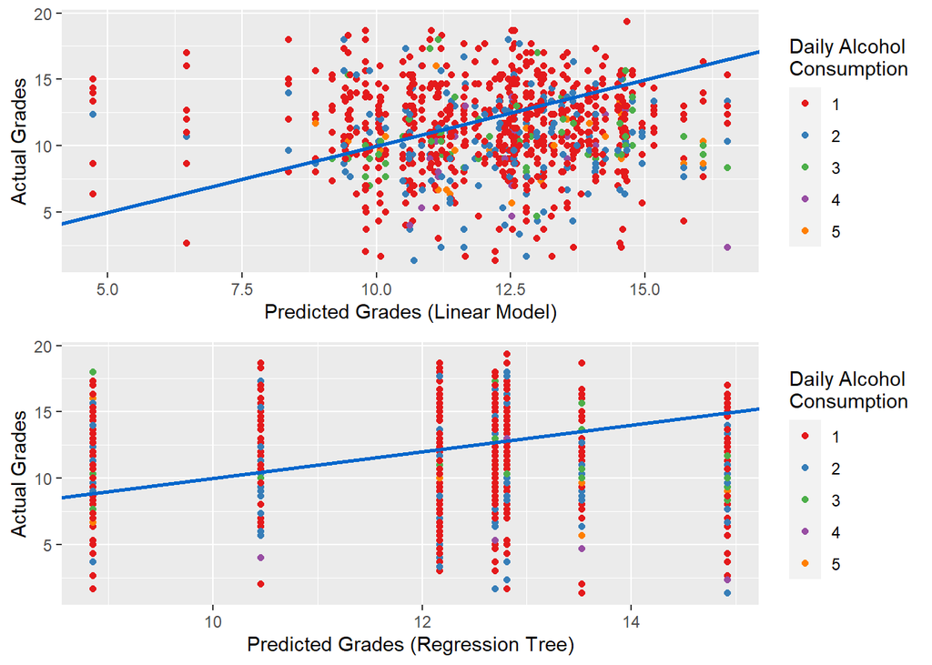

```
## [1] 0.2024795
```

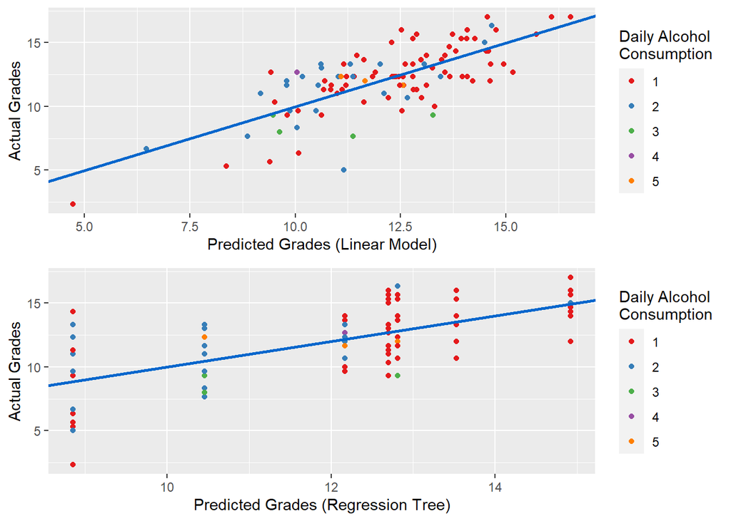

```
## [1] 0.1728394
```

# Random Forest

Below we have commented on our thoughts on the new survey data set and also offered the author’s thoughts on the original data result of Random Forest

Original Dataset: The random forest implementation has an NMSE of 0.2, which is significantly lower than the NMSEs of the linear and regression tree models. As a validation, I will acquire the random forest error plot and compare it to the error plots produced before for the linear and regression tree models.

New Dataset:The random forest implementation has an NMSE of 0.17, which is significantly lower than the NMSEs of the linear and regression tree models. As a validation, I will acquire the random forest error plot and compare it to the error plots produced before for the linear and regression tree models.

[figure not shown]

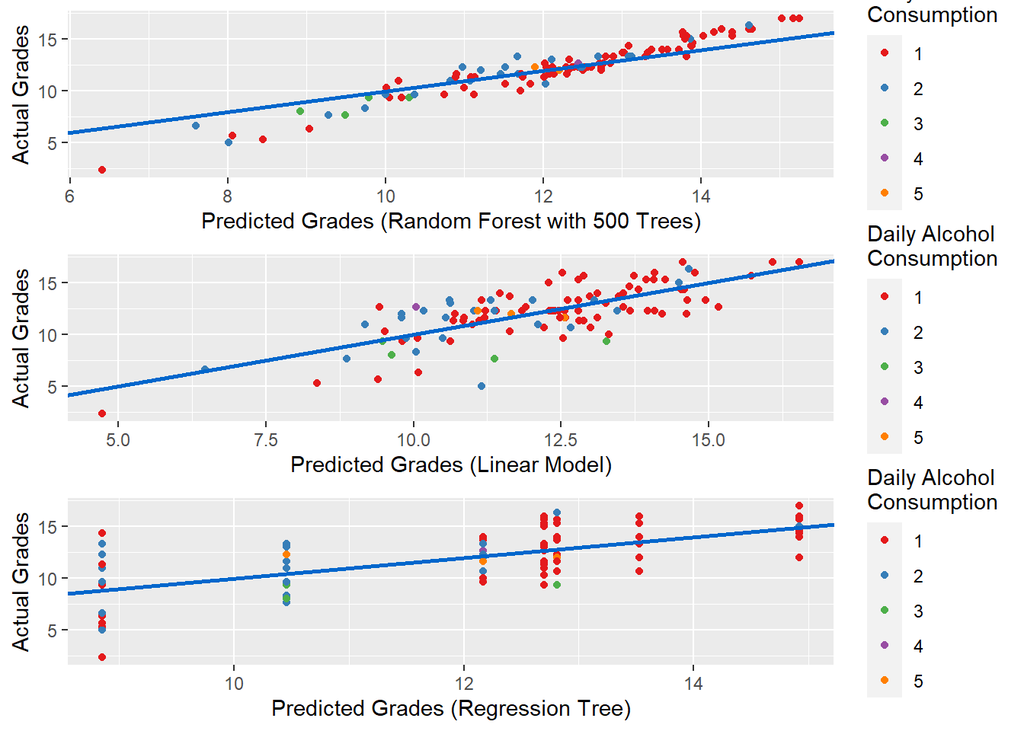

# Conclusion

Original Dataset The findings show that alcohol intake on both weekdays and weekends is an important predictor of student average grades. The removal of each of these two variables increases the MSE of predictions by 10-20%.

What’s remarkable about these results is that certain traits that would be assumed to be essential did not make the top ten list (I would guess that variables like Pstatus, famsupport, famrel, and absences are among those), whilst others (like higher and Medu) turned out to be quite important.

Finally, the effect of the two most relevant factors, “higher” and “medu,” on average student grade is as follows:

higher: a determination to seek higher education raises the average projected grade from 9.42 to 11.25. Thus, encouraging your children to seek higher education is the most effective way to enhance their academic performance! Medu: Increasing the mother’s education from none to more than secondary school raises the expected average grade from 10.8 to 11.5. Thus, future parents (particularly dads) should marry intelligent people if they want their children to do well in school.

New Dataset: On the new dataset we see a completely different approach. Of keynot is the scale and the rearranged order of importance in the variable importance plot. Unlike the original study (where only 2 variables lay below 5%), in the new survey we have barely 7 variables lying on and around 5%+ inclusion in the MSE. The most important is the school with which the student attends and this does have an effect logically as the demographics, teacher staffing and availability of materials does infact impact the psychological perspective of a student

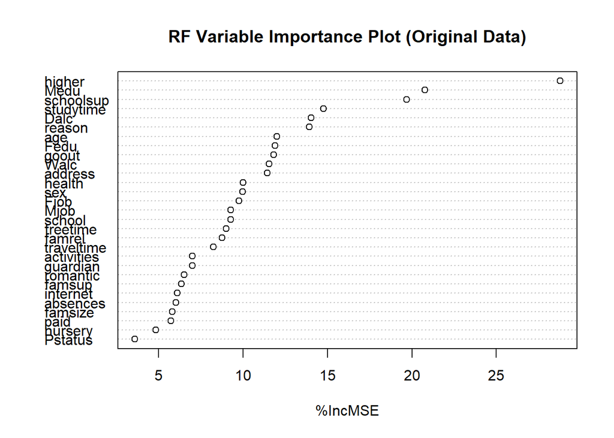

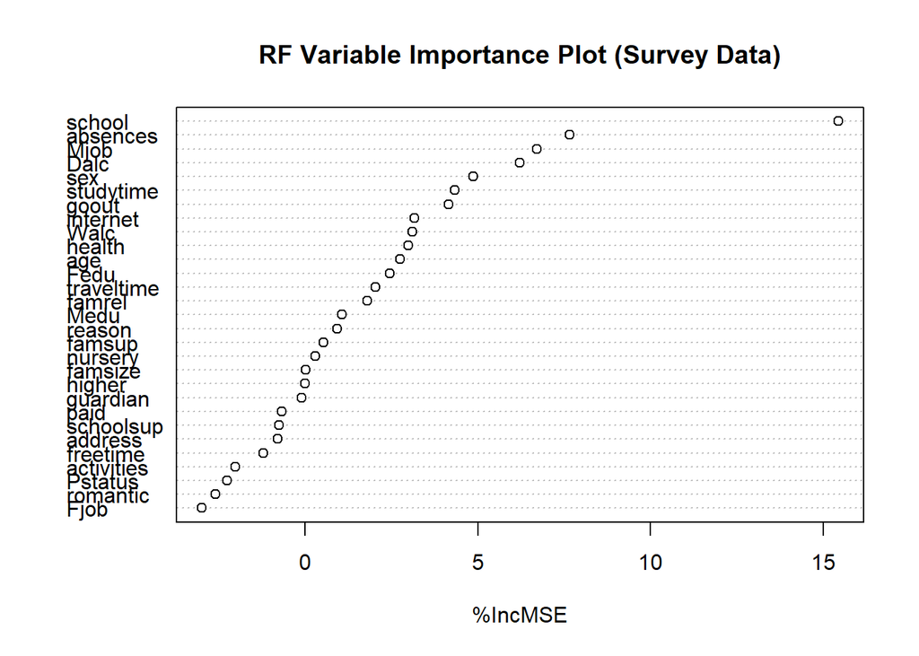